# STA 141C - Big Data & High Performance Statistical Computing Spring 2023

# Homework 1

#### 1. The following facts about triangular matrices are useful for understanding the algorithms that will be

#### mentioned in class. Please create some arbitrary matrices in R or python and verify the following facts:

- The product of two upper triangular matrices is upper triangular.
- The inverse of a lower triangular matrix is lower triangular.
- The product of two unit lower triangular matrices is unit lower triangular.
- The inverse of a unit upper triangular matrix is unit upper triangular.

Note that a unit triangular matrix is a triangular matrix with all diagonal entries being 1.

```python
import numpy as np
A = np.random.rand(3, 3)
# extract the upper triangle of the matrix
A = np.triu(A)

B = np.random.rand(3, 3)
# extract the upper triangle of the matrix
B = np.triu(B)

np.dot(A,B)
```

```
array([[0.58122121, 0.74088138, 1.25779222],
       [0.        , 0.30799586, 0.46606615],
       [0.        , 0.        , 0.15453955]])
```

```python
np.linalg.inv(np.tril(np.random.rand(3, 3)))
```

```
array([[ 1.04022095e+00,  0.00000000e+00,  0.00000000e+00],
       [-1.75675429e+01,  2.51500353e+01,  1.15995405e-16],
       [ 6.65552337e+00, -9.66878060e+00,  1.21713874e+00]])
```

```python
# create two random unit lower triangular matrices of size 3x3
A = np.tril(np.random.rand(3, 3), k=-1) + np.eye(3)
B = np.tril(np.random.rand(3, 3), k=-1) + np.eye(3)

# compute the product of A and B
np.dot(A, B)
```

```
array([[1.        , 0.        , 0.        ],
       [1.28501976, 1.        , 0.        ],
       [0.81103419, 0.52235153, 1.        ]])
```

```python
A = np.triu(np.random.rand(3, 3), k=0)

# Set the diagonal elements to 1 to make it unit upper triangular
A[np.diag_indices(3)] = 1
np.linalg.inv(A)
```

```
array([[ 1.        , -0.34536567, -0.1760714 ],
       [ 0.        ,  1.        , -0.42829282],
       [ 0.        ,  0.        ,  1.        ]])
```

#### 2. Let a = 0.7, b = 0.2, and c = 0.1

- Test whether (a + b) + c equals 1;
- Test whether a + (b + c) equals 1;
- Test whether (a + c) + b equals 1;
- Explain what you found. (For example, you can find the internal representation of these numbers.)

```python
a = 0.7
b = 0.2
c = 0.1
```

```python
(a+b)+c
```

```
0.9999999999999999
```

```python
a + (b+c)
```

```
1.0
```

```python
(a+c)+b
```

```
1.0
```

```python
import struct

# Define a float
x = 0.1

# Pack the float into a bytes object using the "f" format code
x_bytes = struct.pack("f", x)

# Convert the bytes object to an integer
x_int = int.from_bytes(x_bytes, byteorder='big')

# Convert the integer to a binary string
x_binary = bin(x_int)

# Print the original float, its internal representation, its byte representation,
# and its binary representation
print("Original float:", x)
print("Internal representation:", struct.unpack("f", x_bytes)[0])
print("Binary representation:", x_binary)
```

```
Original float: 0.1
Internal representation: 0.10000000149011612
Binary representation: 0b11001101110011001100110000111101
```

We an see that $a+(b+c)$ and $(a+c) + b$ are equal to 1.0 but for $(a+b) + c$ it is represented as a float not exactly equal to 1.0. This is because 0.1 cannot be represented exactly as a base 2 binary fraction.

#### Create the vector x = (0.988, 0.989, 0.990, . . . , 1.010, 1.011, 1.012).

- Plot the polynomial y = x7 − 7x6 + 21x5 − 35x4 + 35x3 − 21x2 + 7x − 1 at each point in x
- Plot the polynomial y = (x − 1)7 at each point in x
- Explain what you found.

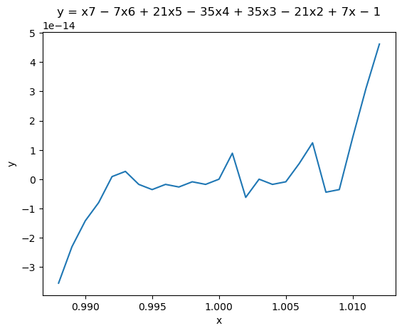

```python
import seaborn as sns
import matplotlib.pyplot as plt

# Define the polynomial function
def polynomial(x):
    return x**7 - 7*x**6 + 21*x**5 - 35*x**4 + 35*x**3 - 21*x**2 + 7*x - 1

# Generate a range of x values
x = np.arange(0.988, 1.013, 0.001)

# Evaluate the polynomial at each x value
y = polynomial(x)

# Create the plot using Seaborn lineplot
sns.lineplot(x=x, y=y)
plt.title("y = x7 − 7x6 + 21x5 − 35x4 + 35x3 − 21x2 + 7x − 1")
plt.xlabel("x")
plt.ylabel("y")
```

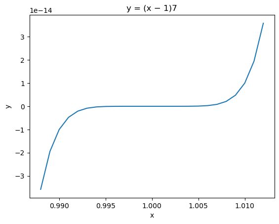

```python
def polynomial(x):
    return (x - 1)**7

# Evaluate the polynomial at each x value
y = polynomial(x)

# Create the plot using Seaborn lineplot
sns.lineplot(x=x, y=y)
plt.title("y = (x − 1)7")
plt.xlabel("x")
plt.ylabel("y")
```

We see that even though these functions are theoretically equivalent floating point approximation errors distort the first plot.

#### 4. Read in the matrix in the file ‘oringp.dat’ on the failure of O-rings leading to the Challenger disaster. The

columns are flight number, date, number of O-rings, number failed, and temperature at launch. Compute the correlation between number of failures and temperature at launch, deleting the last, missing observation (the disaster).

```python
import pandas as pd
column_names = ["flight_number","date","num_o_rings","num_failed","temp"]

o_rings = pd.read_csv("oringp.dat", sep = "\s{1,3}", names = column_names, engine = "python")
o_rings
```

|  | flight_number | date | num_o_rings | num_failed | temp |
| --- | --- | --- | --- | --- | --- |
| 0 | 1 | 4/12/81 | 6 | 0.0 | 66 |
| 1 | 2 | 11/12/81 | 6 | 1.0 | 70 |
| 2 | 3 | 3/22/82 | 6 | 0.0 | 69 |
| 3 | 5 | 11/11/82 | 6 | 0.0 | 68 |
| 4 | 6 | 4/04/83 | 6 | 0.0 | 67 |
| 5 | 7 | 6/18/83 | 6 | 0.0 | 72 |
| 6 | 8 | 8/30/83 | 6 | 0.0 | 73 |
| 7 | 9 | 11/28/83 | 6 | 0.0 | 70 |
| 8 | 41-B | 2/03/84 | 6 | 1.0 | 57 |
| 9 | 41-C | 4/06/84 | 6 | 1.0 | 63 |
| 10 | 41-D | 8/30/84 | 6 | 1.0 | 70 |
| 11 | 41-G | 10/05/84 | 6 | 0.0 | 78 |
| 12 | 51-A | 11/08/84 | 6 | 0.0 | 67 |
| 13 | 51-C | 1/24/85 | 6 | 3.0 | 53 |
| 14 | 51-D | 4/12/85 | 6 | 0.0 | 67 |
| 15 | 51-B | 4/29/85 | 6 | 0.0 | 75 |
| 16 | 51-G | 6/17/85 | 6 | 0.0 | 70 |
| 17 | 51-F | 7/29/85 | 6 | 0.0 | 81 |
| 18 | 51-I | 8/27/85 | 6 | 0.0 | 76 |
| 19 | 51-J | 10/03/85 | 6 | 0.0 | 79 |
| 20 | 61-A | 10/30/85 | 6 | 2.0 | 75 |
| 21 | 61-B | 11/26/85 | 6 | 0.0 | 76 |
| 22 | 61-C | 1/12/86 | 6 | 1.0 | 58 |
| 23 | 61-I | 1/28/86 | 6 | NaN | 31 |

```python
o_rings = o_rings.dropna()
o_rings[["num_failed","temp"]].corr().loc["num_failed","temp"].round(2)
```

```
-0.56
```

#### 5

```python
import random

np.random.seed(42)

def calc_cov(Z, sigma_1, sigma_0):
    """
    Calculates the covariance matrix of a mixed effect model

    Args:
    - Z: numpy array of shape (n, q), design matrix for the random effects
    - sigma_1: float, variance of the random effects
    - sigma_0: float, variance of the error terms

    Returns:
    - cov: numpy array of shape (n, n), covariance matrix of the mixed effect model
    """
    n = Z.shape[0]
    cov = (sigma_1**2 * Z @ Z.T)  + (sigma_0**2 * np.eye(n))
    return cov

n = 100
q = 5
sigma_0 = np.random.rand()
sigma_1 = np.random.rand()

sigma_0_squared = sigma_0**2
sigma_1_squared = sigma_1**2


# generate Z from a q-dimensional normal distribution with mean 0 and variance sigma_1_squared
Z = np.random.normal(loc=0, scale=sigma_1, size=(n, q))
mu = np.random.normal(0, 1, n)


y = np.random.multivariate_normal(mu, calc_cov(Z,sigma_1,sigma_0))


y
```

```
array([-3.48865105e+00,  1.24863667e+00,  2.92556216e+00,  2.81989841e+00,
        1.98043800e+00,  3.88451201e-01,  8.31281848e-01,  7.08486410e-01,
       -7.95321327e-02,  1.25556064e+00, -1.77005207e+00, -2.29596903e+00,
        1.46224493e+00,  2.25808786e+00, -1.77456781e+00, -1.07362194e+00,
        2.00769880e+00,  3.01354311e+00, -2.41652200e+00, -2.36641364e-01,
        1.53387427e+00, -8.15311296e-01, -4.96403047e+00, -4.77810311e+00,
        3.92845845e+00, -2.00659560e+00, -5.40156408e-01, -2.52512160e+00,
       -6.71235807e-01, -4.17060727e+00, -1.12282418e+00,  7.93398114e-02,
        2.44740622e+00,  1.61065090e+00, -6.46892110e-01,  1.41877103e+00,
       -2.62016045e-01,  9.81920811e-01,  4.44797033e+00, -3.60651573e-03,
       -5.66528310e-02,  1.23451594e+00, -2.21306990e+00,  7.50850438e-01,
        5.20562904e+00, -1.07905769e+00,  1.57546608e+00, -1.90755533e-01,
       -1.77034730e+00, -4.96980772e+00,  1.31764943e+00, -2.97821060e+00,
       -1.21130254e+00,  2.51102286e-01,  8.05093663e-01, -1.42585360e+00,
        3.40213378e+00, -2.49366017e-01, -3.31597558e+00, -3.90438923e-01,
        5.61171387e-01, -1.91841400e+00, -2.17939089e-01, -1.07583717e+00,
       -7.05677967e+00, -1.83182245e+00, -8.33304340e-01, -2.14777924e+00,
        8.27031237e-01,  2.41204528e+00,  1.11899965e+00,  7.37964461e-01,
       -2.33176072e-01, -2.20558100e+00, -5.86718956e-01, -4.24057116e+00,
       -2.44514422e+00,  3.58700817e-01, -5.83921084e+00, -8.64542468e-01,
        3.26656731e-01,  2.15362061e+00, -4.52185990e+00, -4.05511504e-02,
       -1.74864524e+00, -2.70907022e+00, -4.13564023e-01,  9.77832605e-01,
       -7.34589919e-01, -6.05282412e-01, -2.61767277e+00,  2.36710008e+00,
       -3.83738658e-01,  1.20594049e+00, -4.83388728e+00, -7.53506952e+00,
       -3.82261329e+00, -3.95036074e+00,  2.20362100e+00,  1.80135325e+00])
```

```python
from scipy.stats import multivariate_normal

log_density = multivariate_normal.logpdf(y, mu, calc_cov(Z,sigma_1,sigma_0))
log_density
```

```
-65.85531724489397
```

$$(A + UV')^{-1} = A^{-1} - A^{-1}U (I_m + V'A^{-1}U)^{-1} V'A^{-1}$$$$det(A + UV') = det(A)det(I_m + V'A^{-1}U)$$$$(\sigma_1^2ZZ' + \sigma_0^2I_n)^{-1}$$

Here we pick

$$A = \sigma_0^2I_n$$$$U = \sigma_1^2Z$$$$V' = Z'$$

We pick these matrices for the decompostion because:

- $\sigma_0^2I_n$ is a diagonal matrix which makes the inverse of $A$ simple to compute.
- $Z'$ has the same amount of rows as U which makes matrix multiplication possible.
- $\sigma_1^2Z$ is the remaining quantity.

Now we can substitute these matrices into the Woodbury Formula:

$$(\sigma_0^2I_n + \sigma_1^2ZZ')^{-1} = \sigma_0^2I_n^{-1} -\sigma_0^2I_n^{-1}\sigma_1^2Z(I_m + Z'\sigma_0^2I_n^{-1}\sigma_1^2Z)^{-1} Z'\sigma_0^2I_n^{-1}$$$$det(\sigma_0^2i_n +\sigma_1^2ZZ') = det(\sigma_0^2I_n)det(I_m + Z'\sigma_0^2I_n^{-1}\sigma_1^2Z)$$

Now we can rewrite the log-density function:

$$-\frac{n}{2}\log(2\pi) - \frac{1}{2}\log(det(\sigma_0^2I_n)det(I_m + Z'\sigma_0^2I_n^{-1}\sigma_1^2Z)) - \frac{1}{2}(y - \mu)'(\sigma_0^2I_n^{-1} -\sigma_0^2I_n^{-1}\sigma_1^2Z(I_m + Z'\sigma_0^2I_n^{-1}\sigma_1^2Z)^{-1} Z'\sigma_0^2I_n^{-1})(y - \mu)$$

```python
import numpy as np
from scipy.linalg import det

def dmvnorm_lowrank(y, mu, Z, sigma_0, sigma_1,log=False):
    n = len(y)
    m = Z.shape[1]

    A = sigma_0**2 * np.eye(n)
    A_inv = np.linalg.inv(A)
    V_prime = Z.T
    U = sigma_1**2 * Z

    # Compute the first term
    first_term = -n/2 * np.log(2*np.pi)

    # Compute the second term
    second_term = (-1/2) * (np.linalg.slogdet(A)[1] + np.log(np.linalg.det(np.eye(m) + V_prime @ A_inv @ U)))

    # Compute the third term
    inv_term = A_inv - (A_inv @ U @ np.linalg.inv(np.eye(m) + V_prime @ A_inv @ U) @ V_prime @ A_inv)
    third_term = -1/2 * (y - mu).T @ inv_term @ (y - mu)

    # Compute the final result
    if log:
        result = first_term + second_term + third_term
    else:
        result = np.exp(first_term + second_term + third_term)

    return result
```

```python
dmvnorm_lowrank(y,mu,Z,sigma_0,sigma_1,True)
```

```
-65.85531724489468
```

```python
import time

start_time = time.time()
multivariate_normal.logpdf(y, mu, calc_cov(Z,sigma_1,sigma_0))
end_time = time.time()
print("The builtin multivariate_normal.logpdf  1 took {:.6f} seconds to execute.".format(end_time - start_time))
```

```
The builtin multivariate_normal.logpdf  1 took 0.001841 seconds to execute.
```

```python
start_time = time.time()
dmvnorm_lowrank(y,mu,Z,sigma_0,sigma_1,True)
end_time = time.time()
print("dmvnorm_lowrank took {:.6f} seconds to execute.".format(end_time - start_time))
```

```
dmvnorm_lowrank took 0.001316 seconds to execute.
```

```python
# redo with larger n
import random

np.random.seed(42)
n = 5000

# generate Z from a q-dimensional normal distribution with mean 0 and variance sigma_1_squared
Z = np.random.normal(loc=0, scale=sigma_1, size=(n, q))
mu = np.random.normal(0, 1, n)
Sigma = calc_cov(Z,sigma_1,sigma_0)


y = np.random.multivariate_normal(mu, calc_cov(Z,sigma_1,sigma_0))

y
```

```
array([ 0.06027012,  0.20960643,  2.85429865, ..., -0.31217099,
       -2.70859796, -0.13817348])
```

```python
multivariate_normal.logpdf(y, mu, Sigma)
```

```
-2341.1758549406886
```

```python
dmvnorm_lowrank(y,mu,Z,sigma_0,sigma_1,True)
```

```
-2341.175854940816
```

```python
import time

start_time = time.time()
multivariate_normal.logpdf(y, mu, Sigma)
end_time = time.time()
print("The builtin multivariate_normal.logpdf  1 took {:.6f} seconds to execute.".format(end_time - start_time))
```

```
The builtin multivariate_normal.logpdf  1 took 21.901256 seconds to execute.
```

```python
start_time = time.time()
dmvnorm_lowrank(y,mu,Z,sigma_0,sigma_1,True)
end_time = time.time()
print("dmvnorm_lowrank took {:.6f} seconds to execute.".format(end_time - start_time))
```

```
dmvnorm_lowrank took 16.797586 seconds to execute.
```

We can see that in both cases where n = 100 and n = 5000 that dmvnorm_lowrank() is faster than the built in equivalent function.

- For n = 100 there was a ~30% decrease in computation time
- For n = 5000 there was a ~23% decrease in computation time

For the n = 5000 case we had to account for the determinat of A being represented as 0 since it is calculated as the product of the diagonal. I avoided this issue by calculating the log determinant and adding instead of multiplying.

#### 6. In class we learnt about the BLAS and how it has become a de facto standard for basic linear algebra

operations. Both R and numpy use the BLAS and LAPACK libraries extensively to accelerate certain types of operations. Apart from *, %*%, eigen, and qr, find out two other common functions use the BLAS and LAPACK routines to speed up calculations.

- numpy.linalg.inv() is a function for matrix inversion. When the argument is a square matrix, numpy.linalg.inv() uses LAPACK routines to compute the inverse efficiently.
- np.linalg.multi_dot() takes multiple arrays as input and performs the matrix multiplication in a way that minimizes the number of temporary arrays created. It achieves this by using BLAS and LAPACK routines to perform the multiplication efficiently.